# Personality in motion: body language and the Big Five

personality

big five

meta-analysis

web apps

data visualization

An interactive field guide to the facial, body and voice cues that a meta-analysis of 65 studies links to the Big Five traits - and to how small those links are.

Luděk Stehlík https://www.linkedin.com/in/ludekstehlik/  
2026-11-22

Recently, I came across an interesting piece of research via a [Minerva Psychology post](https://lnkd.in/p/dxuvsZbZ) about how personality is linked to body language, and how well people’s intuitive theories match the empirical findings in this area.

The study ([Hall et al., 2025](https://doi.org/10.1111/jopy.70030)) asked 245 US adults how likely 20 nonverbal behaviours are for someone high in one of the Big Five traits, and compared their answers with a meta-analysis of 65 studies on how people actually behave ([Breil et al., 2021](https://doi.org/10.1093/oxfordhb/9780190912529.013.13)). For four of the five traits, people’s beliefs matched the evidence fairly well. Openness was the exception.

When reading the paper, I thought that, given the subject of the study, it could be cool and fun to give the main findings a more concrete and interactive form than boring charts and tables. So I built a small app where you pick a trait and an animated figure plays out the facial, body and voice cues that showed a clear link to it in the meta-analysis. (OK, one chart stayed, so you can also see how strong each link is 🙂)

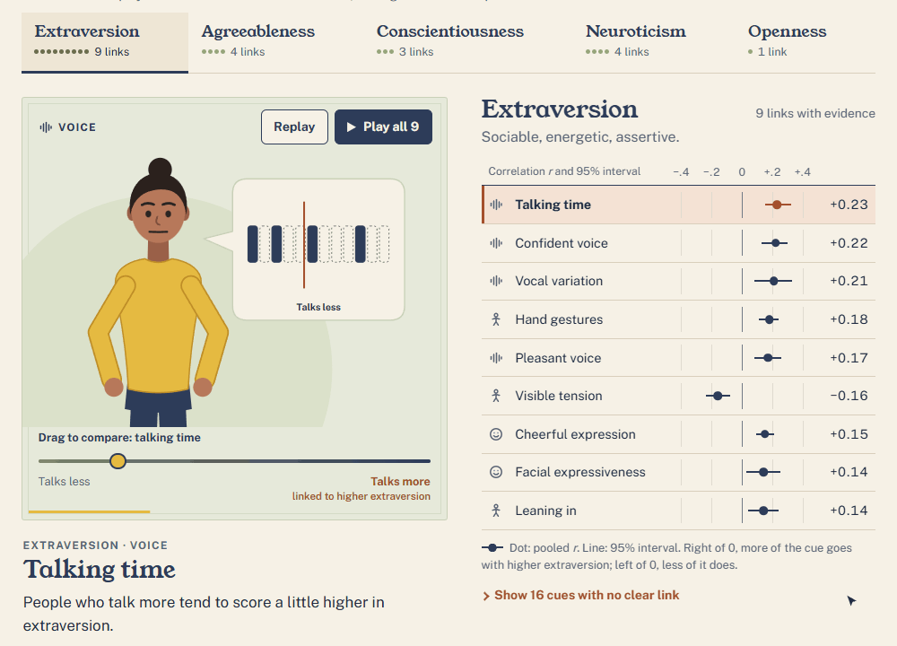

Animated walkthrough of the Personality in motion app: a figure plays out hand gestures, a cheerful expression and leaning in for extraversion, then stride length for agreeableness and self-touch for conscientiousness, next to a chart of each link’s correlation and interval.

Check it out here 👉 [Personality in motion](https://lstehlik2809.github.io/personality_body_language/)

Maybe you’ll find it useful when training body language for a specific persona 🙃